# Summary Plots and Statistics for Glider Odontocete Events

#### Event ID: sg639_07

Time: 2023-04-13 06:02UTC to 2023-04-13 07:45UTC

Event contains 30706 original clicks, **6222 valid clicks** after filtering.

Event contains **16 whistles**.

##### Click plots and table

SNR histogram includes all filtered clicks. Other plots contain only clicks with SNR >= 15 dB (**n = 6128 clicks**) .

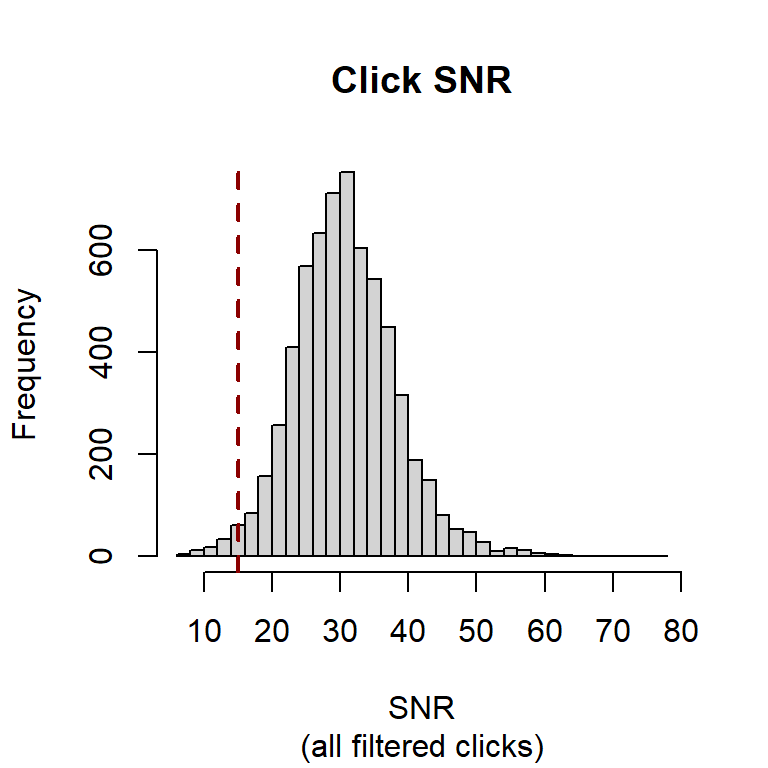

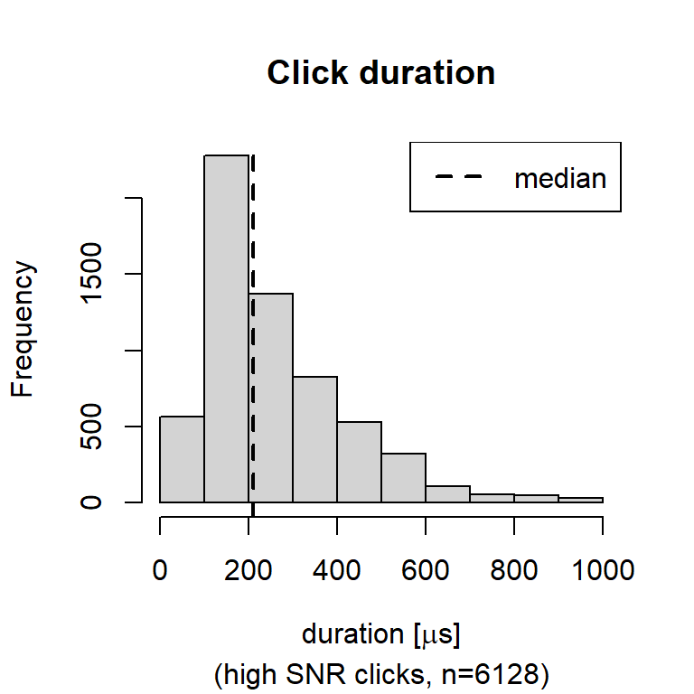

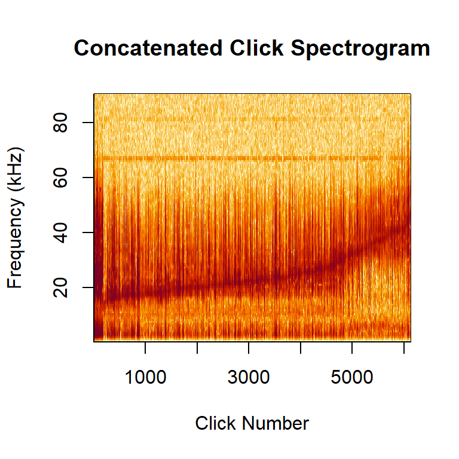

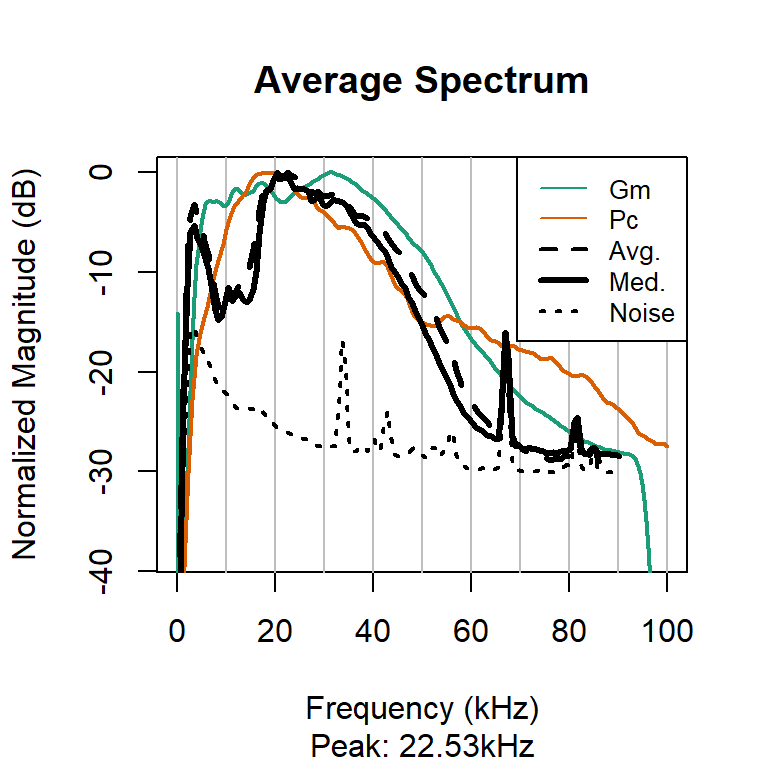

Median statistics for 6128 high SNR clicks with SNR >= 15 dB.

| parameter | value |
| --- | --- |
| Median Peak Frequency [kHz] | 22.3 |
| Median 3dB Center Frequency [kHz] | 22.3 |
| Median 10dB Center Frequency [kHz] | 22.9 |
| Median 3dB Bandwidth [kHz] (lower-upper) | 1.44 (21.4 - 23.3) |
| Median 10dB Bandwidth [kHz] (lower-upper) | 7.11 ( 19 - 26.6) |
| Median duration [μs] (25-75 percentile) | 211 (139 - 328) |

##### Whistle plots and table

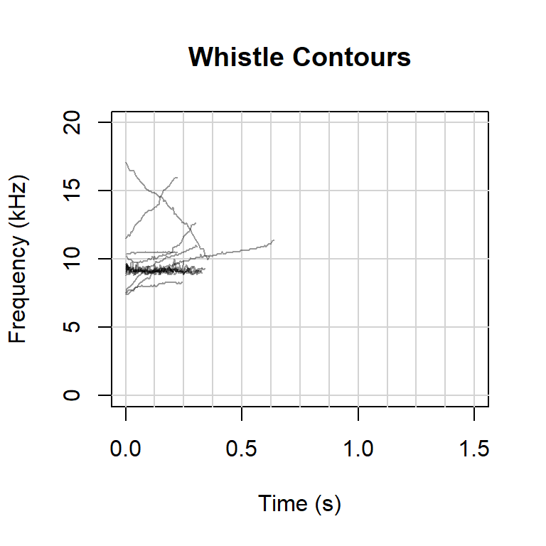

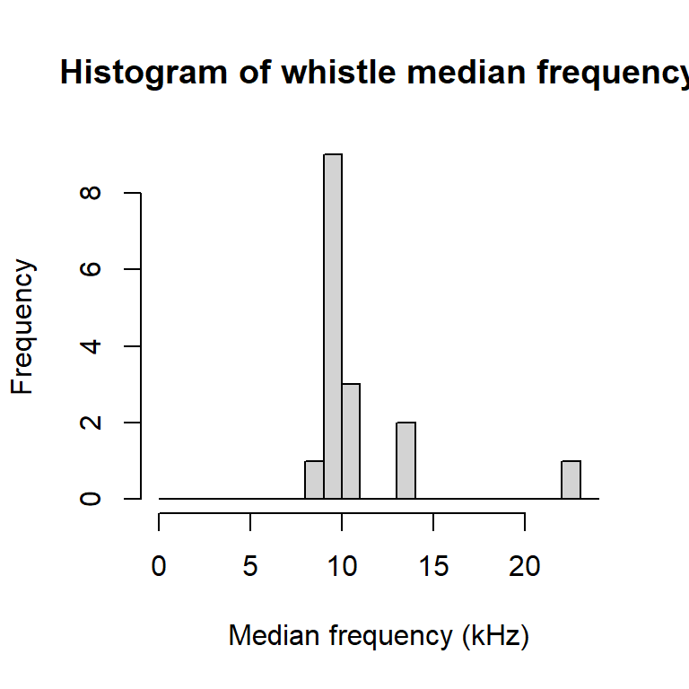

Median statistics for n = 16 whistles.

| parameter | value |
| --- | --- |
| Median begin frequency [kHz] | 9.29 |
| Median end frequency [kHz] | 9.64 |
| Median mean frequency [kHz] (SD) | 9.24 (0.21) |
| Median duration [s] | 0.31 |
| Median frequency range [kHz] (min-max) | 0.88 (8.89 - 9.95) |

#### Event ID: sg639_08

Time: 2023-04-13 12:12UTC to 2023-04-13 14:33UTC

Event contains 107830 original clicks, **12872 valid clicks** after filtering.

Event contains **537 whistles**.

##### Click plots and table

SNR histogram includes all filtered clicks. Other plots contain only clicks with SNR >= 15 dB (**n = 12467 clicks**) .

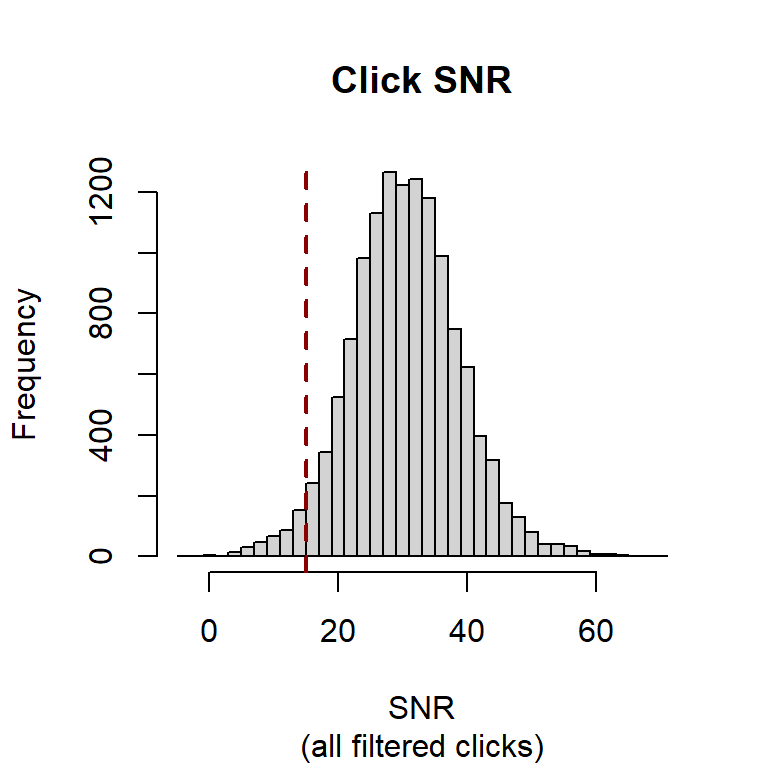

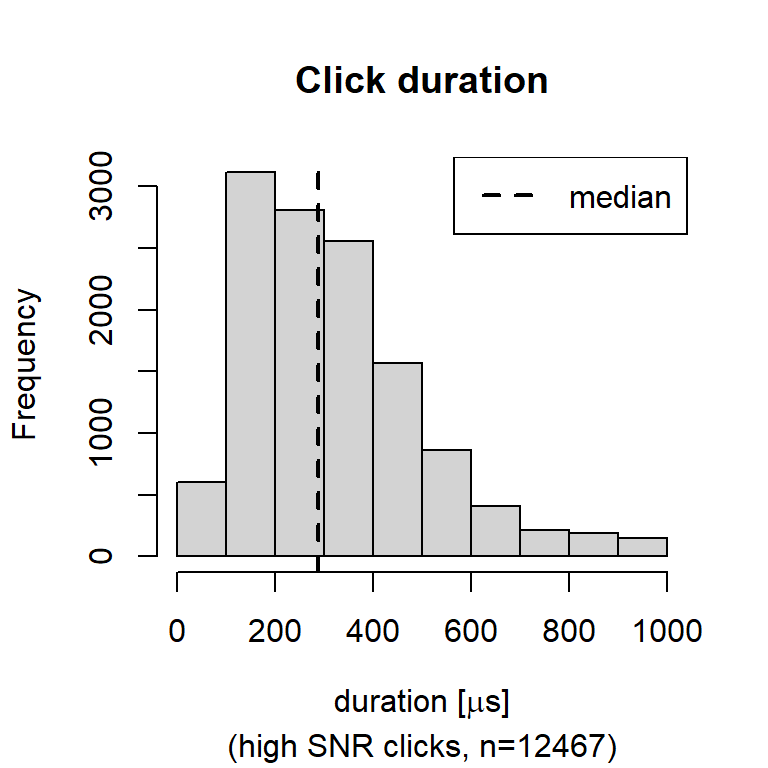

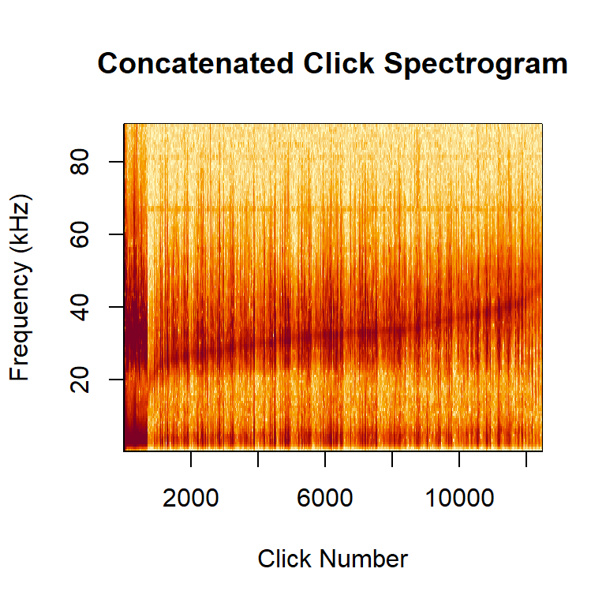

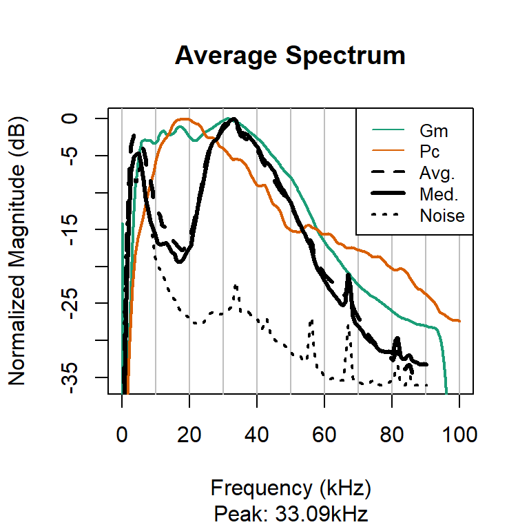

Median statistics for 12467 high SNR clicks with SNR >= 15 dB.

| parameter | value |
| --- | --- |
| Median Peak Frequency [kHz] | 32.3 |
| Median 3dB Center Frequency [kHz] | 32.2 |
| Median 10dB Center Frequency [kHz] | 31.7 |
| Median 3dB Bandwidth [kHz] (lower-upper) | 1.56 (31.4 - 33.1) |
| Median 10dB Bandwidth [kHz] (lower-upper) | 6.99 (28.1 - 35.5) |
| Median duration [μs] (25-75 percentile) | 289 (178 - 411) |

##### Whistle plots and table

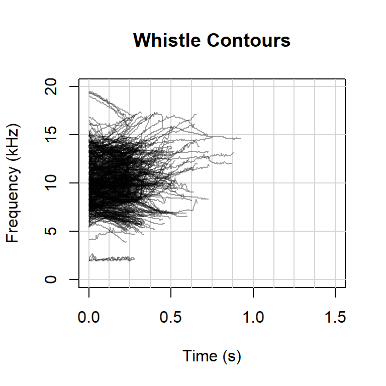

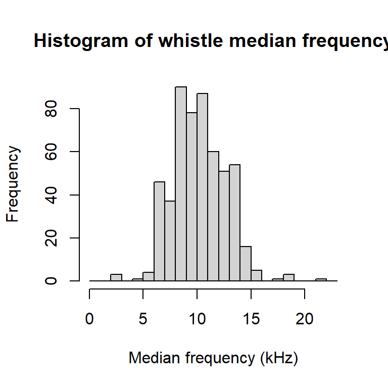

Median statistics for n = 537 whistles.

| parameter | value |
| --- | --- |
| Median begin frequency [kHz] | 9.95 |
| Median end frequency [kHz] | 10.47 |
| Median mean frequency [kHz] (SD) | 10.10 (0.58) |
| Median duration [s] | 0.29 |
| Median frequency range [kHz] (min-max) | 2.11 (9.07 - 11.18) |

#### Event ID: sg639_09

Time: 2023-04-13 15:32UTC to 2023-04-13 16:41UTC

Event contains 43043 original clicks, **6934 valid clicks** after filtering.

Event contains **174 whistles**.

##### Click plots and table

SNR histogram includes all filtered clicks. Other plots contain only clicks with SNR >= 15 dB (**n = 6571 clicks**) .

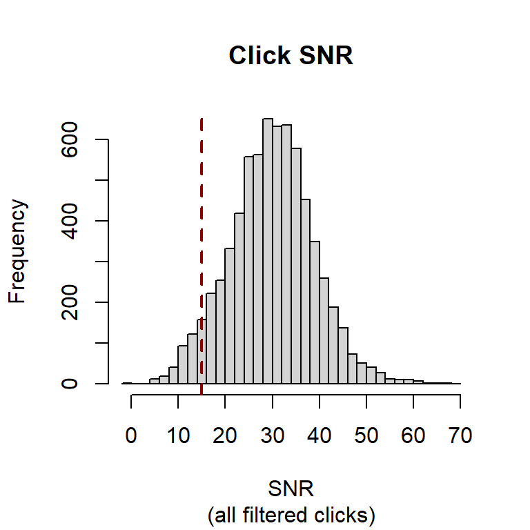

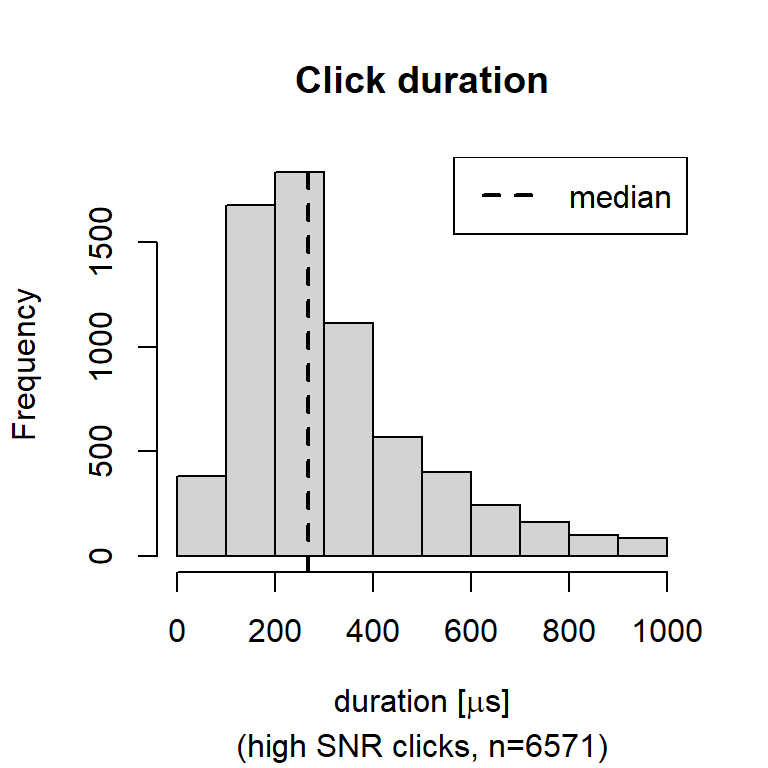

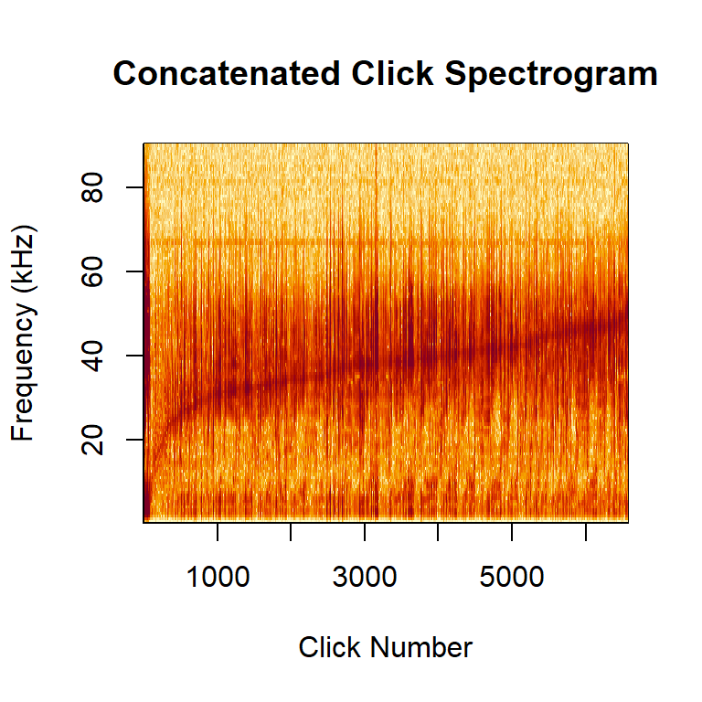

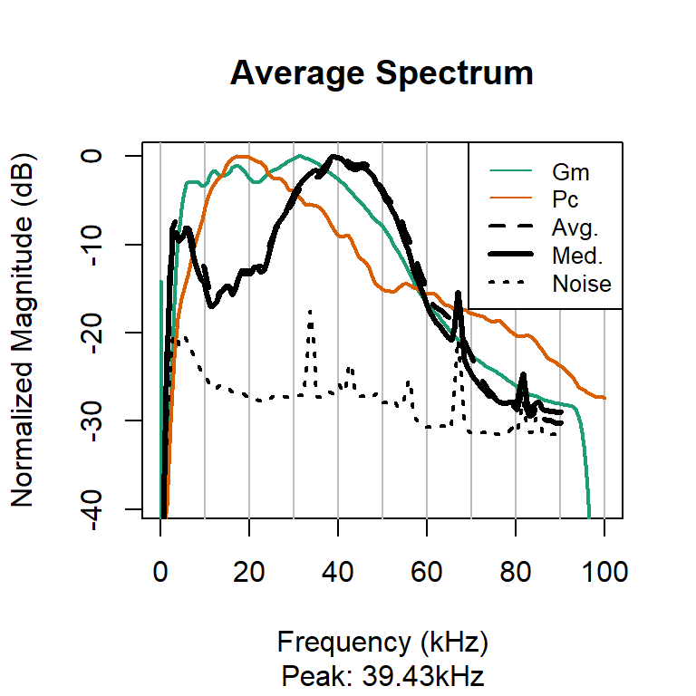

Median statistics for 6571 high SNR clicks with SNR >= 15 dB.

| parameter | value |
| --- | --- |
| Median Peak Frequency [kHz] | 38.3 |
| Median 3dB Center Frequency [kHz] | 37.9 |
| Median 10dB Center Frequency [kHz] | 38.4 |
| Median 3dB Bandwidth [kHz] (lower-upper) | 1.69 (36.7 - 39) |
| Median 10dB Bandwidth [kHz] (lower-upper) | 8.61 (32.8 - 43) |
| Median duration [μs] (25-75 percentile) | 267 (172 - 386) |

##### Whistle plots and table

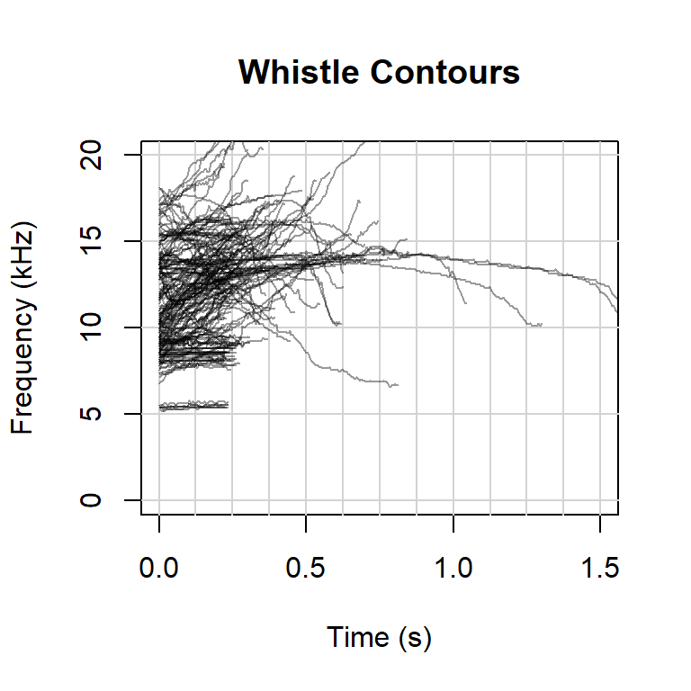

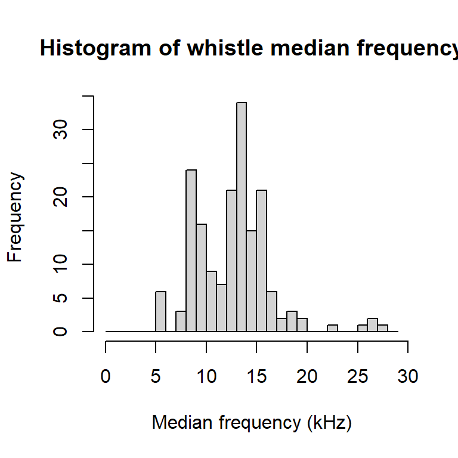

Median statistics for n = 174 whistles.

| parameter | value |
| --- | --- |
| Median begin frequency [kHz] | 10.87 |
| Median end frequency [kHz] | 13.07 |
| Median mean frequency [kHz] (SD) | 12.85 (0.71) |
| Median duration [s] | 0.284 |
| Median frequency range [kHz] (min-max) | 2.38 (10.34 - 14.26) |

#### Event ID: sg639_10

Time: 2023-04-13 17:33UTC to 2023-04-13 17:40UTC

Event contains 28 original clicks, **0 valid clicks** after filtering.

Event contains **36 whistles**.

##### Click plots and table

SNR histogram includes all filtered clicks. Other plots contain only clicks with SNR >= 15 dB (**n = 0 clicks**) .

No clicks of sufficient SNR to plot or summarize.

##### Whistle plots and table

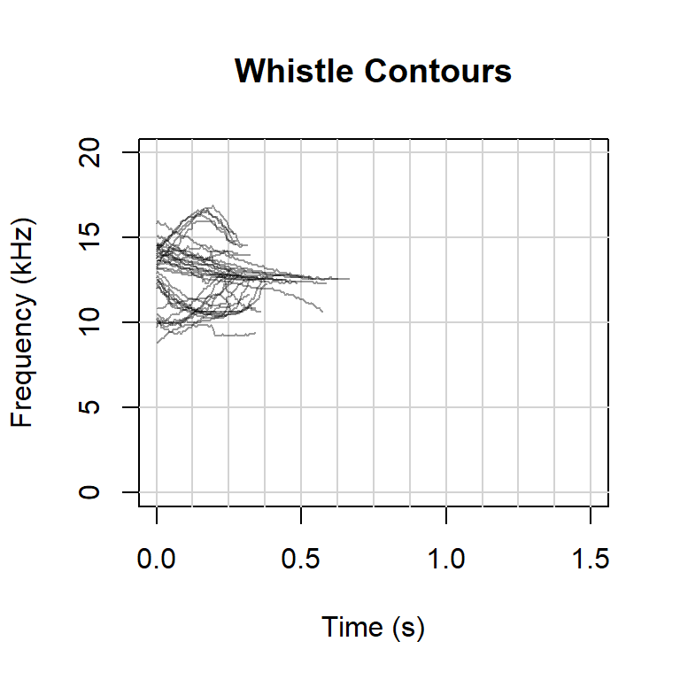

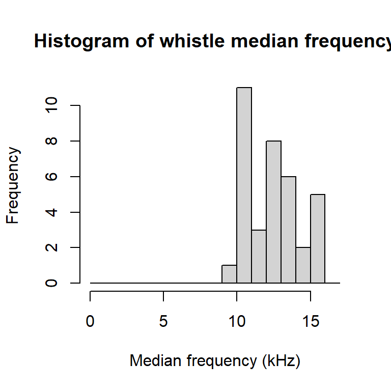

Median statistics for n = 36 whistles.

| parameter | value |
| --- | --- |
| Median begin frequency [kHz] | 13.33 |
| Median end frequency [kHz] | 12.59 |
| Median mean frequency [kHz] (SD) | 12.75 (0.62) |
| Median duration [s] | 0.335 |
| Median frequency range [kHz] (min-max) | 2.11 (12.32 - 13.64) |

#### Event ID: sg639_11

Time: 2023-04-13 23:59UTC to 2023-04-14 00:08UTC

Event contains 2440 original clicks, **53 valid clicks** after filtering.

Event contains **18 whistles**.

##### Click plots and table

SNR histogram includes all filtered clicks. Other plots contain only clicks with SNR >= 15 dB (**n = 52 clicks**) .

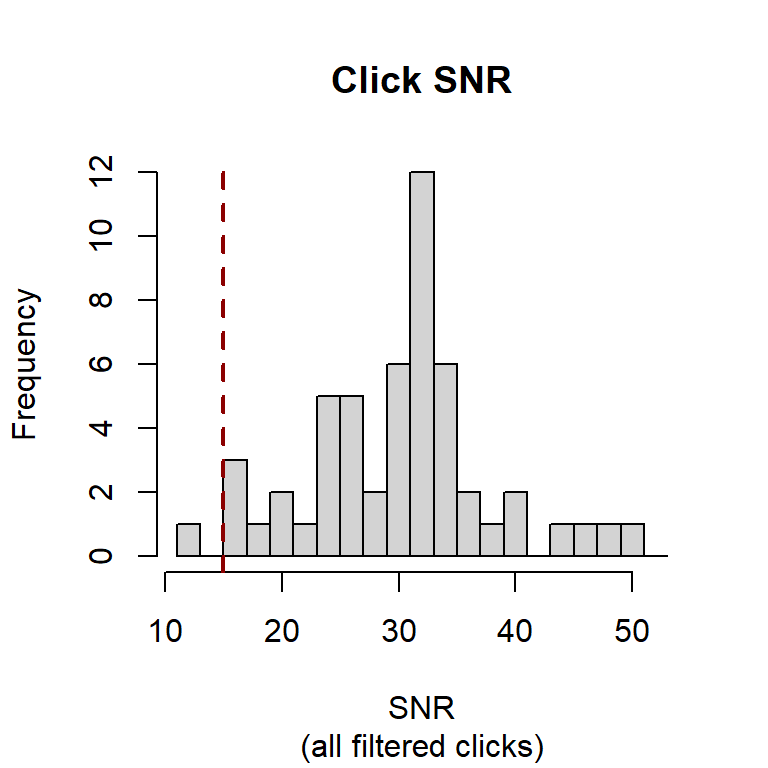

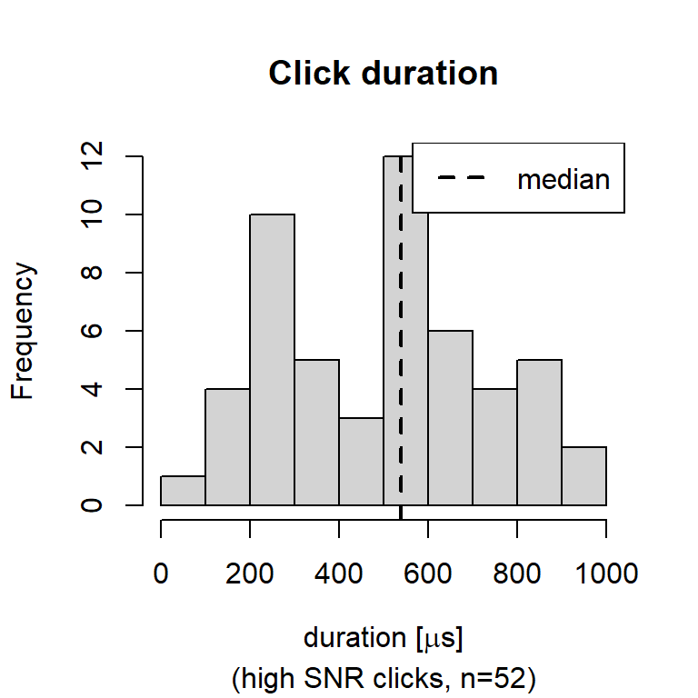

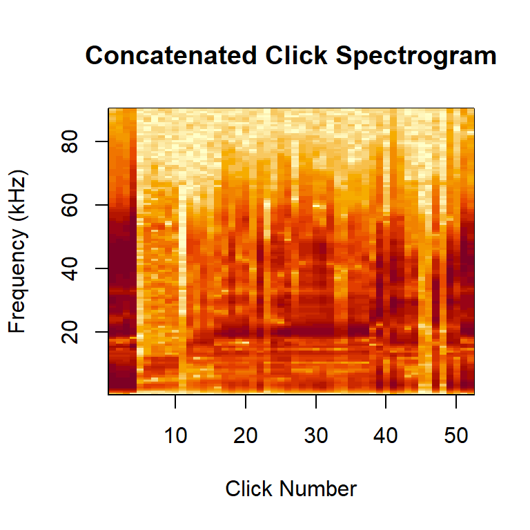

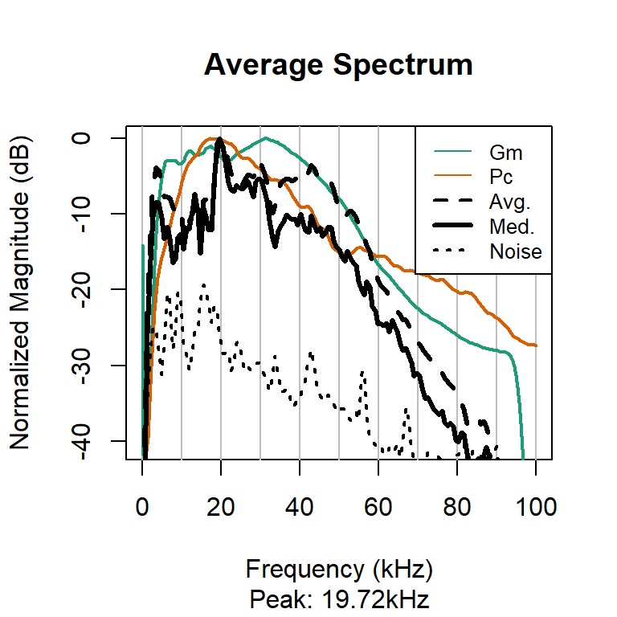

Median statistics for 52 high SNR clicks with SNR >= 15 dB.

[output not shown]

##### Whistle plots and table

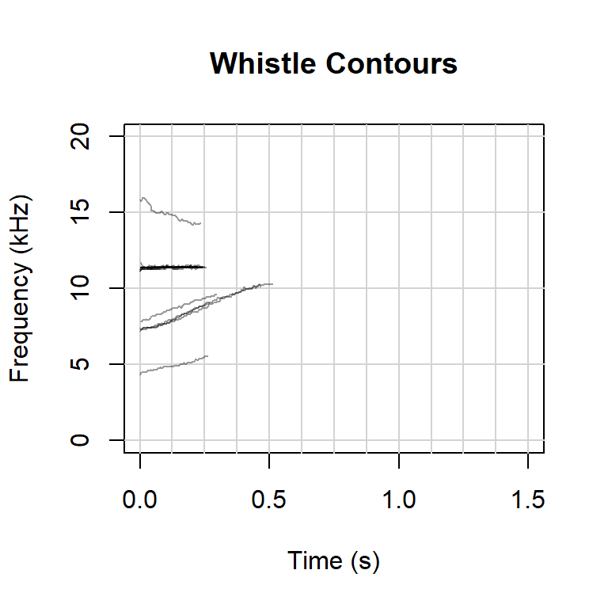

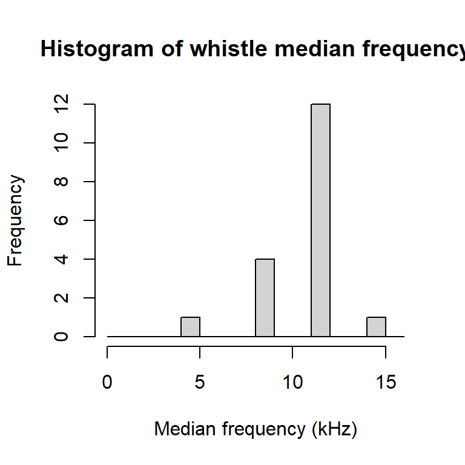

Median statistics for n = 18 whistles.

| parameter | value |
| --- | --- |
| Median begin frequency [kHz] | 11.27 |
| Median end frequency [kHz] | 11.35 |
| Median mean frequency [kHz] (SD) | 11.36 (0.06) |
| Median duration [s] | 0.247 |
| Median frequency range [kHz] (min-max) | 0.26 (11.27 - 11.44) |